# Homework 7 solutions

Author

Ciaran Evans

Total: 44 pts

1. (2 pts)

```r
months <- tolower(lubridate::month(c(12, 1:7), label=T, abbr=F))
months
```

```
[1] "december" "january"  "february" "march"    "april"    "may"      "june"
[8] "july"
```

**Grading:** 2 pts for creating the vector (whichever way they choose)

2. (1 pt)

```r
urls <- paste0("https://www.basketball-reference.com/leagues/NBA_2021_games-",
               months, ".html")
```

**Grading:** 1 pt for running the code

3. (6 pts)

```r
library(rvest)
library(tidyverse)
df_list <- list()

for(i in 1:length(urls)){
  df_list[[i]] <- read_html(urls[i]) |>
    html_element("table") |>
    html_table(header = TRUE, fill = TRUE)
}

df_list[[1]]
```

```
# A tibble: 67 × 11
   Date    `Start (ET)` `Visitor/Neutral`   PTS `Home/Neutral`   PTS ``    ``
   <chr>   <chr>        <chr>             <int> <chr>          <int> <chr> <chr>
 1 Tue, D… 7:00p        Golden State War…    99 Brooklyn Nets    125 Box … ""
 2 Tue, D… 10:00p       Los Angeles Clip…   116 Los Angeles L…   109 Box … ""
 3 Wed, D… 7:00p        Charlotte Hornets   114 Cleveland Cav…   121 Box … ""
 4 Wed, D… 7:00p        New York Knicks     107 Indiana Pacers   121 Box … ""
 5 Wed, D… 7:00p        Miami Heat          107 Orlando Magic    113 Box … ""
 6 Wed, D… 7:00p        Washington Wizar…   107 Philadelphia …   113 Box … ""
 7 Wed, D… 7:30p        New Orleans Peli…   113 Toronto Rapto…    99 Box … ""
 8 Wed, D… 7:30p        Milwaukee Bucks     121 Boston Celtics   122 Box … ""
 9 Wed, D… 8:00p        Atlanta Hawks       124 Chicago Bulls    104 Box … ""
10 Wed, D… 8:00p        San Antonio Spurs   131 Memphis Grizz…   119 Box … ""
# ℹ 57 more rows
# ℹ 3 more variables: Attend. <chr>, Arena <chr>, Notes <lgl>
```

```r
df_list[[2]]
```

```
# A tibble: 222 × 11
   Date    `Start (ET)` `Visitor/Neutral`   PTS `Home/Neutral`   PTS ``    ``
   <chr>   <chr>        <chr>             <int> <chr>          <int> <chr> <chr>
 1 Fri, J… 7:00p        Memphis Grizzlies   108 Charlotte Hor…    93 Box … ""
 2 Fri, J… 7:00p        Miami Heat           83 Dallas Maveri…    93 Box … ""
 3 Fri, J… 7:00p        Boston Celtics       93 Detroit Pisto…    96 Box … ""
 4 Fri, J… 7:30p        Atlanta Hawks       114 Brooklyn Nets     96 Box … ""
 5 Fri, J… 8:00p        Chicago Bulls        96 Milwaukee Buc…   126 Box … ""
 6 Fri, J… 8:00p        Washington Wizar…   130 Minnesota Tim…   109 Box … ""
 7 Fri, J… 8:00p        Los Angeles Lake…   109 San Antonio S…   103 Box … ""
 8 Fri, J… 9:00p        Phoenix Suns        106 Denver Nuggets   103 Box … ""
 9 Fri, J… 9:00p        Los Angeles Clip…   100 Utah Jazz        106 Box … ""
10 Fri, J… 10:30p       Portland Trail B…   123 Golden State …    98 Box … ""
# ℹ 212 more rows
# ℹ 3 more variables: Attend. <chr>, Arena <chr>, Notes <lgl>
```

**Grading:**

- 2 pts for iterating over the urls
- 2 pts for correctly scraping each table
- 2 pts for storing the data frames in a list
4. (1 pt)

```r
library(data.table)

nba <- rbindlist(df_list)
```

**Grading:** 1 pt for running code

5. (6 pts)

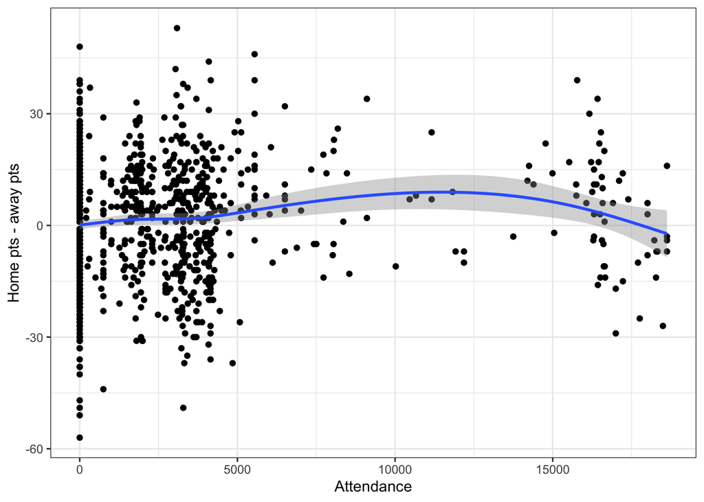

```r
colnames(nba) <- c("date", "start", "visitor", "visitor_pts", "home", "home_pts",
                   "v1", "v2", "attend", "arena", "notes")

nba <- nba |>
  mutate(attend = as.numeric(gsub(",", "", attend)))

nba |>
  mutate(diff = home_pts - visitor_pts) |>
  ggplot(aes(x = attend, y = diff)) +
  geom_point() +
  geom_smooth() +
  theme_bw() +
  labs(x = "Attendance", y = "Home pts - away pts")
```

**Grading:**

- 2 pts for calculating home - away pts (or away - home)
- 2 pts for plotting difference in pts against attendance
- 2 pts for axis labels (something reasonable)
6. (7 pts)

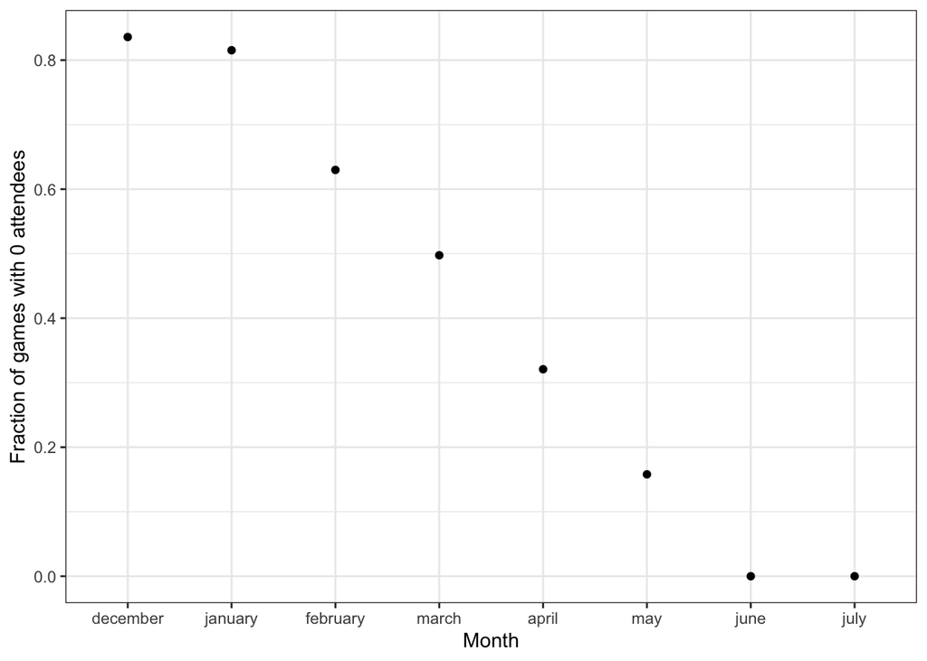

```r
nba |>
  mutate(month = tolower(lubridate::month(lubridate::mdy(date),
                                          label=T, abbr=F))) |>
  mutate(month = factor(month, levels = months)) |>
  group_by(month) |>
  summarize(frac_0 = mean(attend == 0, na.rm=T)) |>
  ggplot(aes(x = month, y = frac_0)) +
  geom_point() +
  theme_bw() +
  labs(x = "Month", y = "Fraction of games with 0 attendees")
```

**Grading:**

- 4 pts for correctly aggregating over reasonable time periods (months, weeks, gamedays, etc.). They lose these points if there is no aggregation
- 2 pts for plotting fraction of 0s against time
- 1 pt for correctly ordering the time axis
7. (2 pts)

```r
table_list <- read_html("https://en.wikipedia.org/wiki/The_Great_British_Bake_Off_(series_2)") |>
  html_elements("table.wikitable.sortable") |>
  html_table()
```

**Grading:** 2 pts for identifying the correct tables (the specific selector they use may vary somewhat)

8. (2 pts)

```r
table_list[[1]]
```

```
# A tibble: 12 × 4
   Baker                      Age Occupation                      Hometown
   <chr>                    <int> <chr>                           <chr>
 1 "Ben Frazer"                31 Graphic Designer                Northampton
 2 "Holly Bell"                31 Advertising executive           Leicester
 3 "Ian Vallance"              40 Fundraiser for English Heritage Dunstable, Be…
 4 "Janet Basu"                63 Teacher of Modern Languages     Formby, Liver…
 5 "Jason White"               19 Civil Engineering Student       Croydon
 6 "Joanne \"Jo\" Wheatley"    41 Housewife                       Ongar, Essex
 7 "Keith Batsford"            31 House husband                   Arlesey, Bedf…
 8 "Mary-Anne Boermans"        45 Housewife                       Kidderminster…
 9 "Robert Billington"         25 Photographer                    London
10 "Simon Blackwell"           31 Rugby Coach                     Norfolk
11 "Urvashi Roe"               40 Head of Marketing               Enfield, Lond…
12 "Yasmin Limbert"            43 Childminder                     West Kirby, T…
```

12 contestants

**Grading:** 2 pts for correct answer

9. (2 pts)

```r
table_list <- read_html("https://en.wikipedia.org/wiki/The_Great_British_Bake_Off_(series_5)") |>
  html_elements("table.wikitable.sortable") |>
  html_table()

table_list[[1]]
```

```
# A tibble: 12 × 5
   `Baker[3]`          Age Occupation                   Hometown           Links
   <chr>             <int> <chr>                        <chr>              <chr>
 1 Chetna Makan         35 Fashion Designer             Broadstairs, Kent  [4][…
 2 Claire Goodwin       31 Speech Therapist             Ashton upon Merse… [6][…
 3 Diana Beard          69 Women's Institute (WI) Judge Alkington, Shrops… [8]
 4 Enwezor Nzegwu       39 Business Consultant          Portsmouth, Hamps… [9]
 5 Iain Watters         31 Construction Engineer        London/Belfast     [10]
 6 Jordan Cox           32 IT Manager                   Sneinton, Notting… [11]…
 7 Kate Henry           41 Furniture Restorer           Brighton, East Su… [13]
 8 Luis Troyano         42 Graphic Designer             Poynton, Cheshire  [14]…
 9 Martha Collison      17 Student                      Ascot, Berkshire   [16]
10 Nancy Birtwhistle    60 Retired Practice Manager     Barton-upon-Humbe… [17]
11 Norman Calder        66 Retired Naval Officer        Portknockie, Moray [18]
12 Richard Burr         38 Builder                      Mill Hill, London  [19]…
```

There is a footnote in the column name

**Grading:** 2 pts for correct answer

10. (3 pts)

```r
table_list <- read_html("https://en.wikipedia.org/wiki/The_Great_British_Bake_Off_(series_5)") |>
  html_elements("table.wikitable.sortable") |>
  html_table()

table_list[[1]] |>
  rename(baker = starts_with("Baker"))
```

```
# A tibble: 12 × 5
   baker               Age Occupation                   Hometown           Links
   <chr>             <int> <chr>                        <chr>              <chr>
 1 Chetna Makan         35 Fashion Designer             Broadstairs, Kent  [4][…
 2 Claire Goodwin       31 Speech Therapist             Ashton upon Merse… [6][…
 3 Diana Beard          69 Women's Institute (WI) Judge Alkington, Shrops… [8]
 4 Enwezor Nzegwu       39 Business Consultant          Portsmouth, Hamps… [9]
 5 Iain Watters         31 Construction Engineer        London/Belfast     [10]
 6 Jordan Cox           32 IT Manager                   Sneinton, Notting… [11]…
 7 Kate Henry           41 Furniture Restorer           Brighton, East Su… [13]
 8 Luis Troyano         42 Graphic Designer             Poynton, Cheshire  [14]…
 9 Martha Collison      17 Student                      Ascot, Berkshire   [16]
10 Nancy Birtwhistle    60 Retired Practice Manager     Barton-upon-Humbe… [17]
11 Norman Calder        66 Retired Naval Officer        Portknockie, Moray [18]
12 Richard Burr         38 Builder                      Mill Hill, London  [19]…
```

**Grading:** 3 pts for renaming the column using `rename` and `starts_with`. Lose 1 pt if they rename it, but use a different method

11. (6 pts)

```r
urls <- paste0("https://en.wikipedia.org/wiki/The_Great_British_Bake_Off_(series_",
               2:13, ")")
contestants <- list()
for(i in 2:13){
  contestants[[i-1]] <- read_html(urls[i-1]) |>
    html_element("table.wikitable.sortable") |>
    html_table() |>
    rename(baker = starts_with("Baker"),
           age = starts_with("Age"),
           occupation = starts_with("occupation"),
           hometown = starts_with("hometown")) |>
    select(baker, age, occupation, hometown) |>
    mutate(series = i)
}

contestants <- rbindlist(contestants)
head(contestants)
```

```
                  baker age                      occupation
1:           Ben Frazer  31                Graphic Designer
2:           Holly Bell  31           Advertising executive
3:         Ian Vallance  40 Fundraiser for English Heritage
4:           Janet Basu  63     Teacher of Modern Languages
5:          Jason White  19       Civil Engineering Student
6: Joanne "Jo" Wheatley  41                       Housewife
                  hometown series
1:             Northampton      2
2:               Leicester      2
3: Dunstable, Bedfordshire      2
4:       Formby, Liverpool      2
5:                 Croydon      2
6:            Ongar, Essex      2
```

**Grading:** 2 pts for iterating over series, 3 pts for correct columns, 1 pt for series column

12. (3 pts)

```r
contestants |>
  group_by(series) |>
  count()
```

```
# A tibble: 12 × 2
# Groups:   series [12]
   series     n
    <int> <int>
 1      2    12
 2      3    12
 3      4    13
 4      5    12
 5      6    12
 6      7    12
 7      8    12
 8      9    12
 9     10    13
10     11    12
11     12    12
12     13    12
```

**Grading:** 3 pts for correct answer

13. (3 pts)

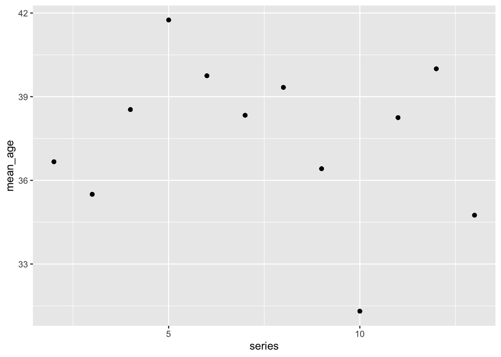

```r
contestants |>
  group_by(series) |>
  mutate(mean_age = mean(age)) |>
  ggplot(aes(x = series, y = mean_age)) +
  geom_point()
```

**Grading:** 3 pts for a reasonable plot or summary statistics